# Statistics 2B - Linear Models Coursework

04/04/2020

## 1. Introduction

### 1.1 Discussion

This analysis is to determine how the popularity of the episodes of the Big Bang Theory relate to the content and production of the show as expressed in the available data. There are many variables available that describe each episode, such as the AirDate, Director, and the number of lines spoken by a range of characters.

### 1.2 Data Mutation

First, let us read in the data.

```r
BigBangTheory = read_csv("BigBangTheory.csv", col_types = cols())
```

We want to mutate the data in order to perform effective analysis:

```r
BigBangTheory %>% mutate(AirDate = as.Date(AirDate, format="%m/%d/%Y"),  Director = factor(Director),
Season = as.numeric(sub("_.*", "", ID)),  Episode = as.numeric(sub(".*_", "", ID)),
ChuckLorre = factor(ifelse(grepl("Chuck Lorre",Writer),"Yes","No")),  Day = weekdays(AirDate),
TotalLines = Leonard+Sheldon+Penny+Howard+Raj+Leslie+Bernadette+Amy+Stuart+Emily+Mary+Zack+Bert+Janine+Wil) -> BigBangTheory
BigBangTheory$Director = relevel(BigBangTheory$Director, ref="Mark Cendrowski")
```

AirDate is now formatted as a date.  
Director is now a factor.  
Season and Episode have been added for convenience.  
ChuckLorre is a Yes/No factor, determining whether Chuck Lorre was involved in that episode or not.  
Day is the day of the week the episode was aired.  
TotalLines is the total lines spoken during each episode by all the actors given combined.

### 1.3 Initial Data Summary

Initially we can see that there are many characters involved in the series, some of which hardly speak. The Directors, Writers, Characters and the Air Date are the information we have to determine what related to the popularity of the show.

```r
summary(BigBangTheory)
```

```
      ID               Title                       Director
 Length:231         Length:231         Mark Cendrowski :203
 Class :character   Class :character   Anthony Rich    : 11
 Mode  :character   Mode  :character   Peter Chakos    :  7
                                       Nikki Lorre     :  3
                                       Howard Murray   :  2
                                       Andrew D. Weyman:  1
                                       (Other)         :  4
    Writer             AirDate               Rating         Leonard
 Length:231         Min.   :2007-09-24   Min.   :6.800   Min.   : 10.00
 Class :character   1st Qu.:2010-04-01   1st Qu.:7.700   1st Qu.: 31.00
 Mode  :character   Median :2012-10-25   Median :8.100   Median : 40.00
                    Mean   :2012-09-09   Mean   :8.036   Mean   : 43.37
                    3rd Qu.:2015-02-12   3rd Qu.:8.350   3rd Qu.: 54.00
                    Max.   :2017-05-11   Max.   :9.200   Max.   :124.00

    Sheldon           Penny           Howard           Raj
 Min.   : 20.00   Min.   : 0.00   Min.   : 1.00   Min.   : 0.0
 1st Qu.: 40.50   1st Qu.:23.00   1st Qu.:16.00   1st Qu.:12.0
 Median : 50.00   Median :31.00   Median :24.00   Median :18.0
 Mean   : 51.54   Mean   :33.29   Mean   :25.77   Mean   :20.5
 3rd Qu.: 62.00   3rd Qu.:42.00   3rd Qu.:34.00   3rd Qu.:28.0
 Max.   :105.00   Max.   :75.00   Max.   :67.00   Max.   :71.0

     Leslie          Bernadette         Amy           Stuart
 Min.   : 0.0000   Min.   : 0.00   Min.   : 0.0   Min.   : 0.000
 1st Qu.: 0.0000   1st Qu.: 0.00   1st Qu.: 0.0   1st Qu.: 0.000
 Median : 0.0000   Median :11.00   Median :15.0   Median : 0.000
 Mean   : 0.4632   Mean   :11.61   Mean   :15.2   Mean   : 3.169
 3rd Qu.: 0.0000   3rd Qu.:20.00   3rd Qu.:25.0   3rd Qu.: 3.000
 Max.   :32.0000   Max.   :46.00   Max.   :63.0   Max.   :36.000

     Emily            Mary              Zack              Bert
 Min.   : 0.00   Min.   : 0.0000   Min.   : 0.0000   Min.   : 0.0000
 1st Qu.: 0.00   1st Qu.: 0.0000   1st Qu.: 0.0000   1st Qu.: 0.0000
 Median : 0.00   Median : 0.0000   Median : 0.0000   Median : 0.0000
 Mean   : 0.71   Mean   : 0.2641   Mean   : 0.5758   Mean   : 0.4199
 3rd Qu.: 0.00   3rd Qu.: 0.0000   3rd Qu.: 0.0000   3rd Qu.: 0.0000
 Max.   :23.00   Max.   :33.0000   Max.   :47.0000   Max.   :25.0000

     Janine             Wil              Season          Episode
 Min.   : 0.0000   Min.   : 0.0000   Min.   : 1.000   Min.   : 1.00
 1st Qu.: 0.0000   1st Qu.: 0.0000   1st Qu.: 3.000   1st Qu.: 6.00
 Median : 0.0000   Median : 0.0000   Median : 6.000   Median :12.00
 Mean   : 0.1342   Mean   : 0.5368   Mean   : 5.662   Mean   :12.14
 3rd Qu.: 0.0000   3rd Qu.: 0.0000   3rd Qu.: 8.000   3rd Qu.:18.00
 Max.   :25.0000   Max.   :23.0000   Max.   :10.000   Max.   :24.00

 ChuckLorre     Day              TotalLines
 No :119    Length:231         Min.   :118.0
 Yes:112    Class :character   1st Qu.:189.0
            Mode  :character   Median :208.0
                               Mean   :207.6
                               3rd Qu.:227.0
                               Max.   :309.0
```

From the numerical summary of the data, we can tell that there were a total of 231 episodes of The Big Bang Theory over Seasons 1-10, which ran from 2007 to 2017.  
The main Director of the show was Mark Cendrowski.  
The show was overall rated highly at a median average of 8.1.  
Sheldon spoke the most lines across the 10 seasons, at a mean average of 51.54 lines per episode.  
The total lines spoken in each episode median averaged at 208.

Before looking into the ratings, it is useful to know how involved each character was in the show, as from the summary we can see some characters barely spoke at all:

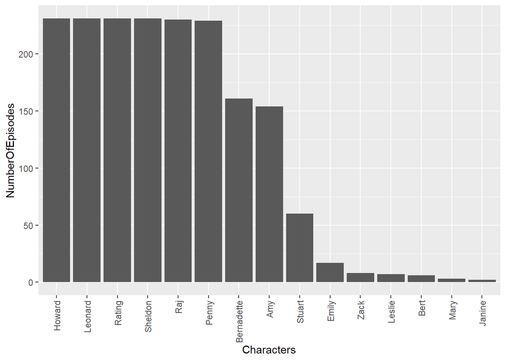

```r
data.frame(NumberOfEpisodes = sort(colSums(BigBangTheory[,6:20] != 0),decreasing = TRUE)) -> d
d = rownames_to_column(d,"Characters")
d$Characters = reorder(d$Characters,-d$NumberOfEpisodes)
ggplot(d,aes(y=NumberOfEpisodes)) + theme(axis.text.x=element_text(angle=90,hjust=1,vjust=0.5)) + geom_bar(aes(x=Characters), stat = "identity")
```

The Characters Emily, Wil, Zack, Leslie, Bert, Mary and Janine did not appear in many episodes. Due to this it is important to note they will not be ideal predictors for a linear model, as there is hardly any evidence supporting that they had any effect.

It is also made clear that the main characters of the show are Howard, Leonard, Sheldon, Raj and Penny, followed by Amy and Bernadette in later seasons.

```r
BigBangTheory %>% mutate(AirDate = as.numeric(AirDate)) -> BigBangTheory2
BigBangTheory2 %>% select(AirDate,Leonard,Sheldon,Penny,Howard,Raj) %>% cor()
```

```
            AirDate    Leonard     Sheldon       Penny      Howard        Raj
AirDate  1.00000000 -0.4937715 -0.34748122 -0.19687782 -0.05864457  0.1648235
Leonard -0.49377148  1.0000000  0.30051432  0.22903901 -0.19202378 -0.2210169
Sheldon -0.34748122  0.3005143  1.00000000  0.05191438 -0.22618262 -0.2281450
Penny   -0.19687782  0.2290390  0.05191438  1.00000000 -0.14519379 -0.2129093
Howard  -0.05864457 -0.1920238 -0.22618262 -0.14519379  1.00000000  0.2537158
Raj      0.16482354 -0.2210169 -0.22814496 -0.21290927  0.25371584  1.0000000
```

A good way to see relationships between variables is to look at a correlation matrix. This is taking the main Characters of the show, and seeing whether they relate to each other, and the AirDate. Amy and Bernadette have not been included in the matrix. This is due to Amy and Bernadette’s appearance later on in the series - this will need to be taken into consideration when analysing the data.

The correlations are fairly large, which are important to note - these variables have an impact on each other that needs to be taken into consideration when analysing the data, it may be hard for example to determine which character is truly responsible for the raise/decline in Rating.

Another useful aspect of the data to know before looking into the ratings is how involved each variable was in the show over time.  
Some of the variable plots have been omitted from the report due to the fact there is clearly no inference to be taken from them.

```r
p1 = ggplot(BigBangTheory,aes(AirDate,TotalLines)) + geom_point()
p2 = ggplot(BigBangTheory,aes(AirDate,Day)) + geom_point()
p3 = ggplot(BigBangTheory,aes(AirDate,Leonard)) + geom_point()
p4 = ggplot(BigBangTheory,aes(AirDate,Sheldon)) + geom_point()
p5 = ggplot(BigBangTheory,aes(AirDate,Penny)) + geom_point()
p6 = ggplot(BigBangTheory,aes(AirDate,Howard)) + geom_point()
p7 = ggplot(BigBangTheory,aes(AirDate,Raj)) + geom_point()
p8 = ggplot(BigBangTheory,aes(AirDate,Bernadette)) + geom_point()
p9 = ggplot(BigBangTheory,aes(AirDate,Amy)) + geom_point()
p10 = ggplot(BigBangTheory,aes(AirDate,Stuart)) + geom_point()
p11 = ggplot(BigBangTheory,aes(AirDate,Director)) + geom_point()
```

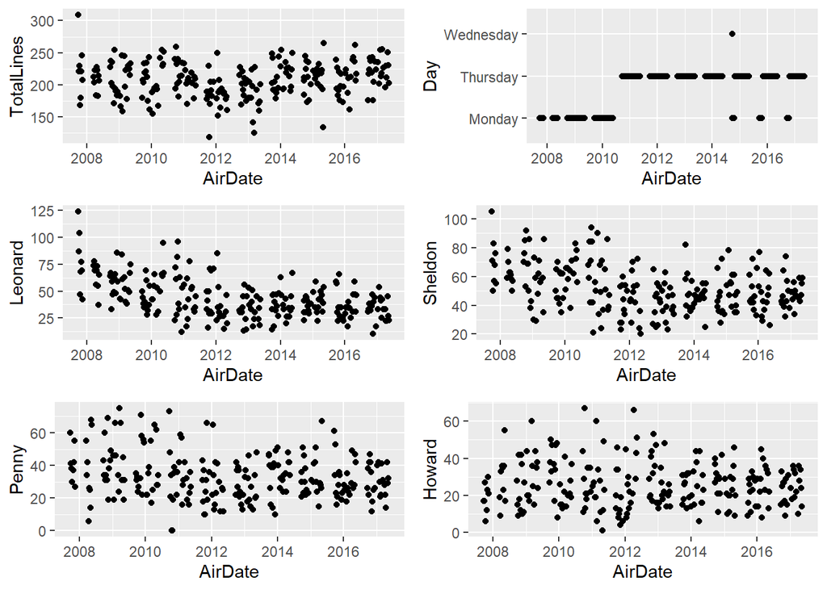

```r
grid.arrange(p1,p2,p3,p4,p5,p6)
```

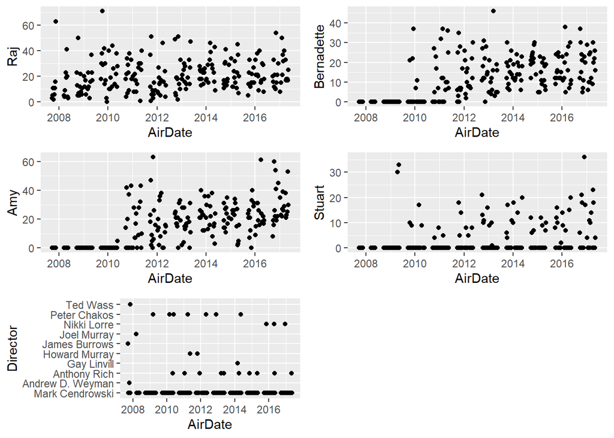

```r
grid.arrange(p7,p8,p9,p10,p11)
```

As shown in the graphs, Leonard and Sheldon spoke less over time, while Raj spoke more, despite the total lines remaining fairly regular.  
This may be due to the introduction of the new main Characters later on in the series; Amy and Bernadette.  
However this is just speculation at this point.

Another key thing to notice is the one episode which aired on a Wednesday, which is peculiar. Let’s investigate this further.

```r
BigBangTheory %>% filter(Day == 'Wednesday')
```

```
# A tibble: 1 x 26
  ID    Title Director Writer AirDate    Rating Leonard Sheldon Penny Howard
  <chr> <chr> <fct>    <chr>  <date>      <dbl>   <dbl>   <dbl> <dbl>  <dbl>
1 8_3   The ~ Mark Ce~ Chuck~ 2014-09-24    7.1      41      39    36     40
# ... with 16 more variables: Raj <dbl>, Leslie <dbl>, Bernadette <dbl>,
#   Amy <dbl>, Stuart <dbl>, Emily <dbl>, Mary <dbl>, Zack <dbl>, Bert <dbl>,
#   Janine <dbl>, Wil <dbl>, Season <dbl>, Episode <dbl>, ChuckLorre <fct>,
#   Day <chr>, TotalLines <dbl>
```

After reviewing this information online, it appears as though this episode actually aired on 29/09/14 rather than 24/09/14. This was probably a data entry error so we rectify it in the data frame.

```r
BigBangTheory[162,] = BigBangTheory[162,] %>% mutate(AirDate = as.Date.character("2014-09-29"), Day = weekdays(as.Date.character("2014-09-29")))
```

## 2 The Effect of Air Date on the Ratings

Now we want to analyse whether the Air Date had an effect on the ratings.

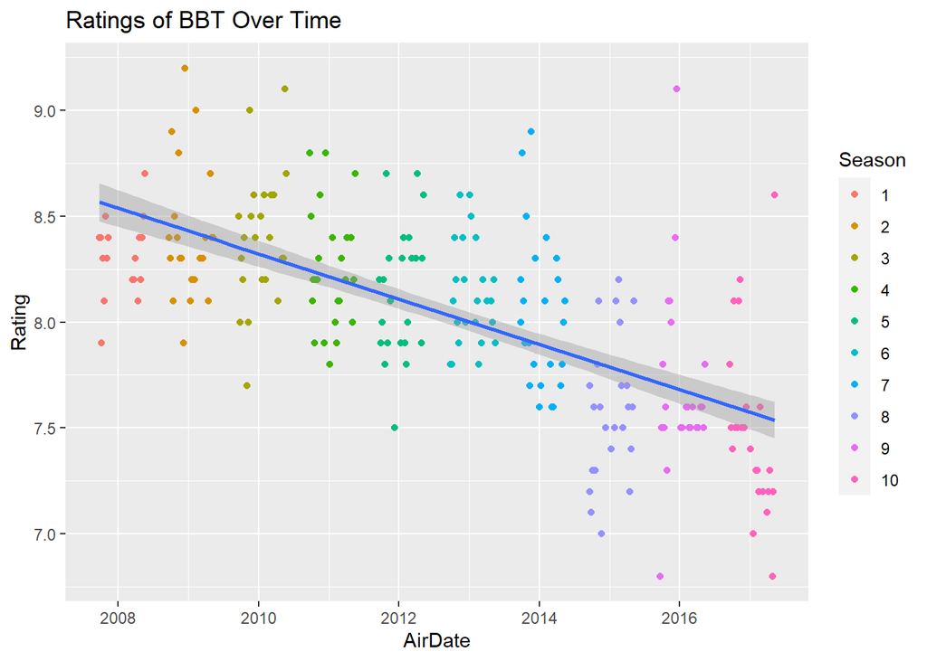

```r
ggplot(BigBangTheory, aes(x=AirDate, y=Rating)) + geom_point(aes(colour=factor(Season))) + labs(colour="Season") + ggtitle("Ratings of BBT Over Time") + geom_smooth(method="lm")
```

We see immediately that the later the AirDate, the lower the rating. But did the rating of episodes change within each Season?

### 2.1 The Rating of Episodes Within Each Season

Here are some graphical representations of how the rating of episodes changes throughout each season.

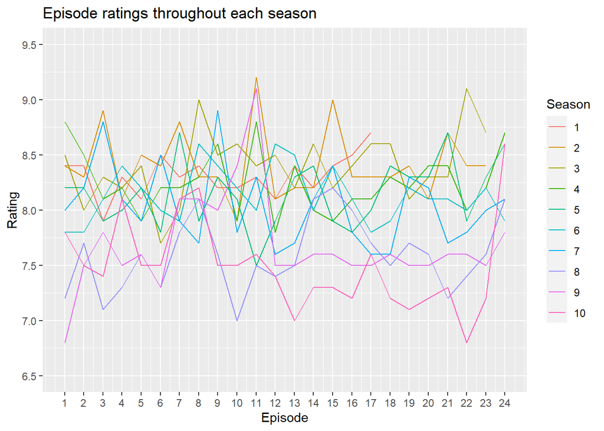

```r
ggplot(BigBangTheory, aes(x=Episode, y=Rating, colour=factor(Season))) + geom_line() + scale_x_continuous(breaks = seq(1,24)) + scale_y_continuous(limits = c(6.5,9.5), breaks = seq(6.5,10.0,0.5)) + ggtitle("Episode ratings throughout each season") + labs(colour="Season")
```

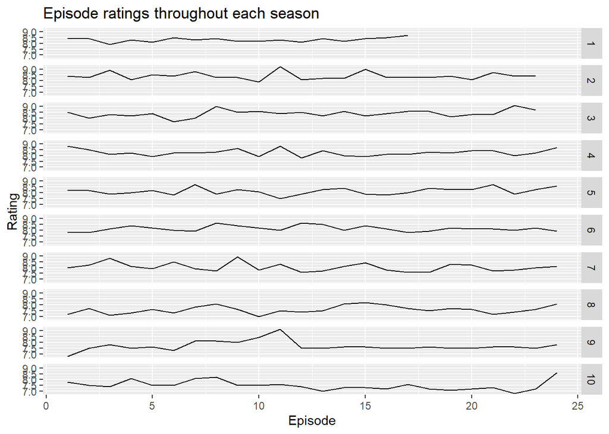

```r
ggplot(BigBangTheory,aes(Episode, Rating)) + geom_line() + facet_grid(rows = vars(Season)) + ggtitle("Episode ratings throughout each season")
```

To determine whether rating of episodes varied throughout the season, we can consider a linear model with Rating as the response and Episode as the predictor. As not all seasons have the same number of episodes, we instead consider ‘percentage of the way through the current season’ as our predictor. We add ‘Percentage’ as a variable in our data:

```r
  BigBangTheory =  BigBangTheory %>% mutate(Percentage =
      ifelse(Season == 1, 100 * Episode/ nrow(BigBangTheory %>% filter(Season==1)),
      ifelse(Season == 2, 100 * Episode/ nrow(BigBangTheory %>% filter(Season==2)),
      ifelse(Season == 3, 100 * Episode/ nrow(BigBangTheory %>% filter(Season==3)),
      ifelse(Season == 4, 100 * Episode/ nrow(BigBangTheory %>% filter(Season==4)),
      ifelse(Season == 5, 100 * Episode/ nrow(BigBangTheory %>% filter(Season==5)),
      ifelse(Season == 6, 100 * Episode/ nrow(BigBangTheory %>% filter(Season==6)),
      ifelse(Season == 7, 100 * Episode/ nrow(BigBangTheory %>% filter(Season==7)),
      ifelse(Season == 8, 100 * Episode/ nrow(BigBangTheory %>% filter(Season==8)),
      ifelse(Season == 9, 100 * Episode/ nrow(BigBangTheory %>% filter(Season==9)),
                          100 * Episode/ nrow(BigBangTheory %>% filter(Season==10))))))))))))
```

We fit a model using Percentage as the predictor and Rating as the response.

```r
pmod = lm(Rating ~ Percentage, BigBangTheory)
```

To see if Percentage is a significant predictor, we test the null hypothesis $H_0: \beta = 0$ vs. the alternative hypothesis $H_1: \beta \neq 0$.

```r
library(broom)
tidy(pmod)
```

```
# A tibble: 2 x 5
  term        estimate std.error statistic   p.value
  <chr>          <dbl>     <dbl>     <dbl>     <dbl>
1 (Intercept) 8.03       0.0622    129.    6.69e-216
2 Percentage  0.000199   0.00104     0.191 8.49e-  1
```

We see that the p-value of the t-statistic is 0.8491. This is a very high p-value so we do not reject the null hypothesis and Percentage is not a significant predictor. Hence we conclude that rating did not change within each season; ratings did not generally increase or decrease throughout.

This is very useful for us to know - since the ratings within each season generally remained stable, the AirDate and Season can be used interchangably in our models depending on what is required.

## 3 The Effect of Other Variables on the Rating

Now we want to see if any other variables had an effect on the Rating.  
Again, some of the variable plots have been omitted from the report due to the fact there is clearly no inference to be taken from them.

```r
p1 = ggplot(BigBangTheory,aes(TotalLines,Rating)) + geom_point()
p2 = ggplot(BigBangTheory,aes(Day,Rating)) + geom_jitter(width=0.1)
p3 = ggplot(BigBangTheory,aes(Leonard,Rating)) + geom_point()
p4 = ggplot(BigBangTheory,aes(Sheldon,Rating)) + geom_point()
p5 = ggplot(BigBangTheory,aes(Penny,Rating)) + geom_point()
p6 = ggplot(BigBangTheory,aes(Howard,Rating)) + geom_point()
p7 = ggplot(BigBangTheory,aes(Raj,Rating)) + geom_point()
p8 = ggplot(BigBangTheory,aes(Bernadette,Rating)) + geom_point()
p9 = ggplot(BigBangTheory,aes(Amy,Rating)) + geom_point()
p10 = ggplot(BigBangTheory,aes(Stuart,Rating)) + geom_point()
p11 = ggplot(BigBangTheory,aes(Rating,Director)) + geom_point()
```

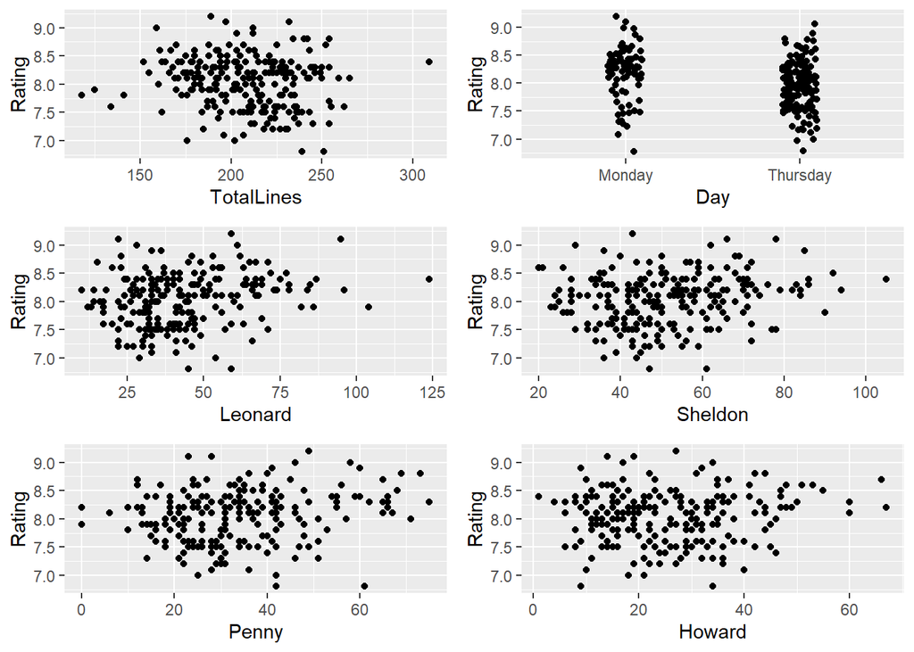

```r
grid.arrange(p1,p2,p3,p4,p5,p6)
```

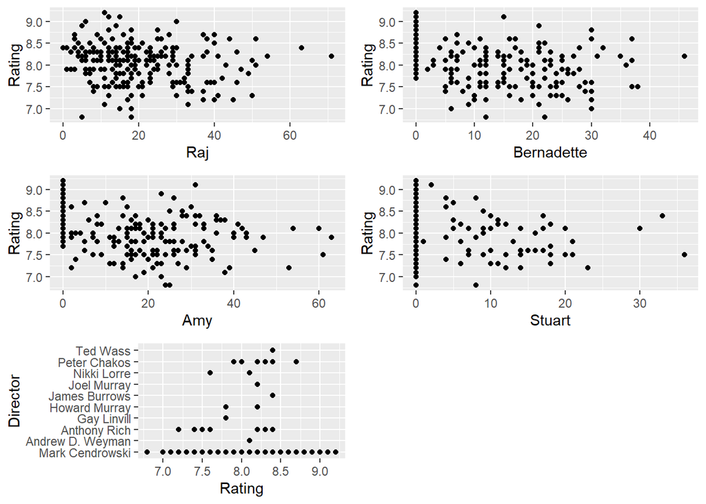

```r
grid.arrange(p7,p8,p9,p10,p11)
```

These graphs tend to show little to no correlation, perhaps Leonard has a slightly positive effect - it is not visually clear.

### 3.1 A Model to Determine Significance of the Predictors

Our initial model will include all the predictors we have available:

```r
lmod = lm(Rating~Season+Director+ChuckLorre+Leonard+Sheldon+Penny+Howard+Raj+Leslie+Bernadette+Amy+Stuart+Emily+Mary+Zack+Bert+Janine+Wil+Day, BigBangTheory)
```

This clearly has too many predictors. It is best for us to immediately simplify this model:

```r
lmodr = step(lmod, trace=FALSE)
```

We need to check the diagnostics of this model.

```r
dmodr = augment(lmodr)
dmodr %>% arrange(desc(.resid))
```

```
# A tibble: 231 x 12
   Rating Season Leonard Penny Day   .fitted .se.fit .resid    .hat .sigma
    <dbl>  <dbl>   <dbl> <dbl> <chr>   <dbl>   <dbl>  <dbl>   <dbl>  <dbl>
 1    9.1      9      22    23 Thur~    7.70  0.0382  1.40  0.0131   0.321
 2    8.6     10      23    32 Thur~    7.59  0.0421  1.01  0.0159   0.328
 3    9.1      3      95    28 Mond~    8.10  0.0717  1.00  0.0462   0.328
 4    8.9      7      36    41 Thur~    7.97  0.0323  0.934 0.00936  0.329
 5    8.8      7      46    40 Thur~    7.93  0.0329  0.868 0.00971  0.329
 6    9.2      2      59    49 Mond~    8.40  0.0431  0.796 0.0166   0.330
 7    8.4      9      25    19 Thur~    7.67  0.0391  0.726 0.0137   0.331
 8    8.1     10      33    42 Mond~    7.43  0.0720  0.671 0.0466   0.331
 9    8.7      5      71    24 Thur~    8.06  0.0539  0.637 0.0260   0.332
10    8.2     10      10    12 Thur~    7.57  0.0550  0.630 0.0271   0.332
# ... with 221 more rows, and 2 more variables: .cooksd <dbl>, .std.resid <dbl>
```

Nothing appears particually unusual about the episode with the highest residual. It has one of the highest ratings despite being later on in the series.

```r
dmodr %>% arrange(desc(.hat))
```

```
# A tibble: 231 x 12
   Rating Season Leonard Penny Day   .fitted .se.fit  .resid   .hat .sigma
    <dbl>  <dbl>   <dbl> <dbl> <chr>   <dbl>   <dbl>   <dbl>  <dbl>  <dbl>
 1    8.4      1     124    60 Mond~    8.36  0.102   0.0352 0.0941  0.335
 2    8.2      4      96     0 Thur~    8.04  0.101   0.159  0.0907  0.334
 3    7.9      4      82     0 Thur~    8.08  0.0860 -0.184  0.0663  0.334
 4    8.8      4      23    73 Thur~    8.49  0.0857  0.307  0.0659  0.334
 5    8.3      5      85    65 Thur~    8.15  0.0825  0.153  0.0611  0.334
 6    7.3      9      66    21 Mond~    7.39  0.0788 -0.0906 0.0558  0.335
 7    6.8      9      59    61 Mond~    7.54  0.0775 -0.736  0.0539  0.331
 8    8.3      2      40    75 Mond~    8.54  0.0769 -0.243  0.0531  0.334
 9    7.9      1     104    38 Mond~    8.36  0.0765 -0.459  0.0525  0.333
10    7.4     10      38    22 Mond~    7.35  0.0747  0.0485 0.0501  0.335
# ... with 221 more rows, and 2 more variables: .cooksd <dbl>, .std.resid <dbl>
```

No particular residual has a high leverage, so no need for outliers to be removed if there are any.

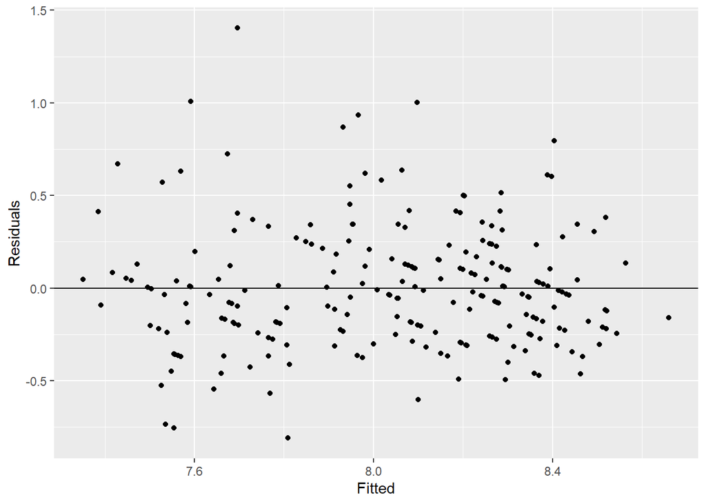

```r
dmodr = augment(lmodr)
ggplot(dmodr,aes(.fitted,.resid)) + geom_point() + geom_hline(yintercept = 0) + xlab("Fitted") + ylab("Residuals")
```

There is no non-constant variance, no non-linearity and no excessive outliers, so this is fine.

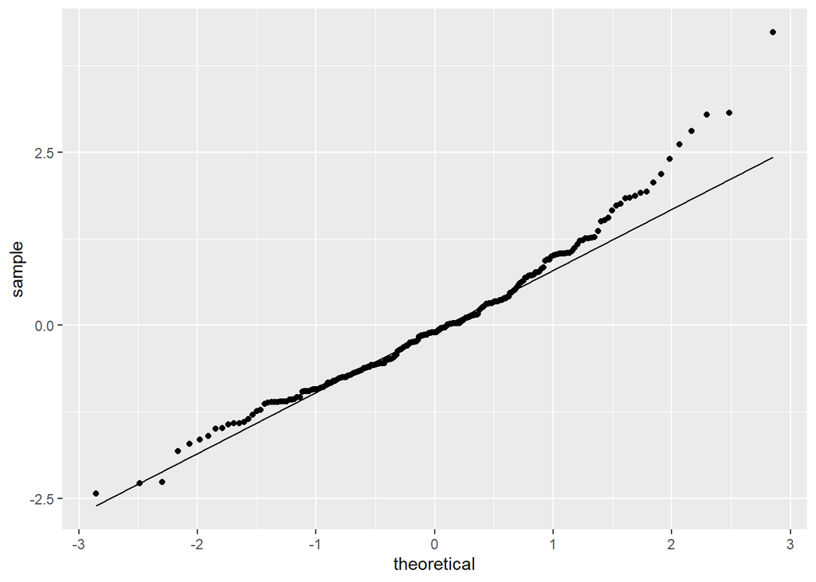

```r
ggplot(dmodr,aes(sample=.std.resid)) + stat_qq() + stat_qq_line()
```

A little divergence on the upper tail but overall safe to assume errors are normally distributed.

Can safely assume this model is appropriate to use in determining significance of the variables.

### 3.2 Searching for Outliers in our Model

The largest studentized residuals for the BigBangTheory Rating model sorted by absolute value are:

```r
BigBangTheory = column_to_rownames(BigBangTheory,"ID") #Changing ID to rownames for better idenification of each episode in the dataset
tail(sort(abs(rstudent(lmodr))))
```

```
     169      138      144      231       62      194
2.462661 2.646711 2.853903 3.103582 3.134113 4.403043
```

We compute the critical value for declaring an outlier using the Bonferroni correction as:

```r
qt(.05/(231*2),231-2-1)
```

```
[1] -3.75942
```

The episode 9_11 meets the outlier criterion by exceeding 3.75942 in absolute value.

```r
BigBangTheory['9_11',]
```

```
                            Title        Director
9_11 The Opening Night Excitation Mark Cendrowski
                                           Writer    AirDate Rating Leonard
9_11 Steven Molaro & Eric Kaplan & Tara Hernandez 2015-12-17    9.1      22
     Sheldon Penny Howard Raj Leslie Bernadette Amy Stuart Emily Mary Zack Bert
9_11      66    23     14  15      0         15  31      2     0    0    0    0
     Janine Wil Season Episode ChuckLorre      Day TotalLines Percentage
9_11      0   9      9      11         No Thursday        197   45.83333
```

This episode does not appear to be particularly unusual - it just has a very high rating despite being later on in the series.

### 3.3 Interpreting our Model

```r
summary(lmodr)
```

```
Call:
lm(formula = Rating ~ Season + Leonard + Penny + Day, data = BigBangTheory)

Residuals:
    Min      1Q  Median      3Q     Max
-0.8095 -0.2267 -0.0335  0.1645  1.4042

Coefficients:
             Estimate Std. Error t value Pr(>|t|)
(Intercept)  8.694147   0.114180  76.144  < 2e-16 ***
Season      -0.129243   0.010019 -12.900  < 2e-16 ***
Leonard     -0.003110   0.001414  -2.200  0.02882 *
Penny        0.003091   0.001609   1.921  0.05595 .
DayThursday  0.162155   0.057095   2.840  0.00492 **
---
Signif. codes:  0 '***' 0.001 '**' 0.01 '*' 0.05 '.' 0.1 ' ' 1

Residual standard error: 0.3338 on 226 degrees of freedom
Multiple R-squared:  0.4737,    Adjusted R-squared:  0.4644
F-statistic: 50.85 on 4 and 226 DF,  p-value: < 2.2e-16
```

This suggests that the Season is a very significant variable, and adds a lot of explanatory power even when we know the other predictors. The Day of the week and how many lines Leonard has are also significant predictors in the model determining the Rating. Penny is not a significant predictor in the model yet she was included - this suggests she has little to no overall effect on the rating, but can be somewhat useful alongside other predictors in determining the Rating.

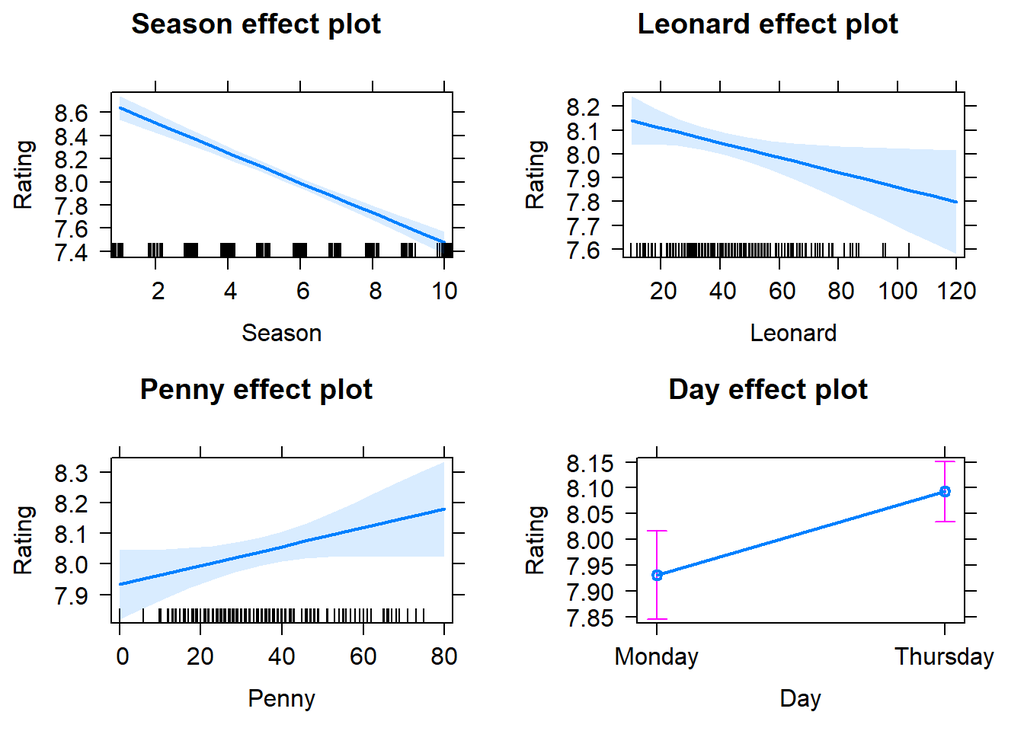

```r
p1 = plot(effect("Season",lmodr))
p2 = plot(effect("Leonard",lmodr))
p3 = plot(effect("Penny",lmodr))
p4 = plot(effect("Day",lmodr))
grid.arrange(p1,p2,p3,p4)
```

As can be seen with the effects plots, later seasons generally had more poorly rated episodes in them. The more Leonard spoke, the less popular the episode was in general, and episodes aired on a Thursday were generally more highly rated. Penny appears to have a somewhat positive but not conclusive effect on the Rating.

Something to note is the fact that in our initial graphs Leonard appeared to have a somewhat positive effect on the Rating. Let us explore this:

```r
lm(Rating ~ Leonard, BigBangTheory) %>% tidy()
```

```
# A tibble: 2 x 5
  term        estimate std.error statistic   p.value
  <chr>          <dbl>     <dbl>     <dbl>     <dbl>
1 (Intercept)  7.80      0.0753     104.   2.67e-194
2 Leonard      0.00546   0.00160      3.41 7.59e-  4
```

When used as a singular predictor, Leonard does indeed have a significant positive effect on the Rating. This is due to the correlation between AirDate and Leonard, as shown below:

```r
BigBangTheory2 %>% select(AirDate,Leonard) %>% cor()
```

```
           AirDate    Leonard
AirDate  1.0000000 -0.4937715
Leonard -0.4937715  1.0000000
```

Leonard is heavily negatively correlated to the AirDate. Since the AirDate is a much more significant predictor in determining the Rating, when it is not involved in the linear model the relationship between it and the predictors actually become much more relevant than the direct relationship between the predictors and the Rating. So this explains why Leonard appears to have a positive effect in our graphs, when in actuality it is negative.

## 4 Further Exploration of the Model

### 4.1 Why is the Day relevant?

We should also explore why the Day may have had an effect on the rating.

This is a plot to visualise which episode aired on either day:

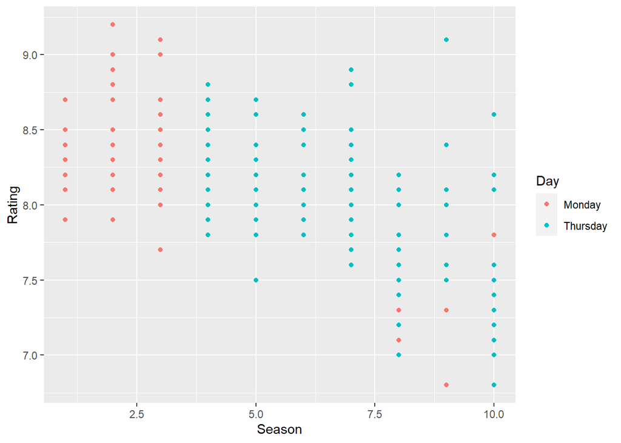

```r
ggplot(BigBangTheory, aes(Season, Rating, colour = (Day))) + geom_point() + labs(colour = 'Day')
```

Interestingly, for the first three seasons episodes were aired on a Monday, while the other seasons aired on a Thursday, bar a handful of episodes. The fact the Day is significant suggests that the first three seasons did not rate as highly as expected, when taking the assumption that there is a linear relationship between the Rating and the AirDate.

The graph does appear to be not quite linear. However, our model assumptions held - it was acceptable to assume linearity between the Rating and the AirDate. The Day the episode aired may have had a genuine impact, for example Monday is a less favoured day, therefore people watching on that day could have had their opinions of the episode influenced by this. It is hard to be certain of the effect.

### 4.2 Why is Chuck Lorre not relevant?

Chuck Lorre is known as the King of Sitcoms, yet he was removed when simplifying our model. Let us see why:

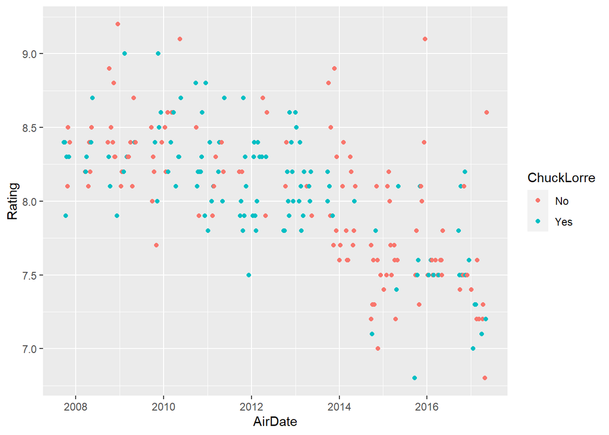

```r
ggplot(BigBangTheory,aes(AirDate,Rating,color=ChuckLorre)) + geom_point()
```

This plot graphically describes the difference between the episodes where Chuck Lorre was involved and where he was not involved. The coloured dots are very mixed suggesting there is very little if any correlation between Chuck Lorre’s writing and the Rating.

```r
BigBangTheory %>% t.test(Rating ~ ChuckLorre, data=.)
```

```
    Welch Two Sample t-test

data:  Rating by ChuckLorre
t = -1.1976, df = 227.33, p-value = 0.2323
alternative hypothesis: true difference in means is not equal to 0
95 percent confidence interval:
 -0.18922917  0.04616195
sample estimates:
 mean in group No mean in group Yes
         8.001681          8.073214
```

The p-value is high when evaluating Chuck Lorre as a singular predictor. It is safe to say that he did not have an effect on the popularity of the episodes.

### 4.3 Is the total number of lines spoken relevant?

One thing we want to consider is whether the total number of lines spoken as a whole has an effect on the Rating.

Firstly let us see whether the the linear model we have can be improved by replacing the characters with TotalLines:

```r
lmodr2 = lm(Rating ~ Season+TotalLines+Day, BigBangTheory)
anova(lmodr2, lmodr)
```

```
Analysis of Variance Table

Model 1: Rating ~ Season + TotalLines + Day
Model 2: Rating ~ Season + Leonard + Penny + Day
  Res.Df    RSS Df Sum of Sq     F   Pr(>F)
1    227 25.970
2    226 25.186  1   0.78334 7.029 0.008588 **
---
Signif. codes:  0 '***' 0.001 '**' 0.01 '*' 0.05 '.' 0.1 ' ' 1
```

This is a significant p-value, so our model has not improved.

On a separate note the model assumptions do indeed hold for lmodr2.

```r
summary(lmodr2)
```

```
Call:
lm(formula = Rating ~ Season + TotalLines + Day, data = BigBangTheory)

Residuals:
     Min       1Q   Median       3Q      Max
-0.82688 -0.22972 -0.05452  0.16259  1.40753

Coefficients:
              Estimate Std. Error t value Pr(>|t|)
(Intercept)  8.7496956  0.1772289  49.369  < 2e-16 ***
Season      -0.1213373  0.0096282 -12.602  < 2e-16 ***
TotalLines  -0.0006225  0.0008305  -0.749  0.45435
DayThursday  0.1574398  0.0567752   2.773  0.00602 **
---
Signif. codes:  0 '***' 0.001 '**' 0.01 '*' 0.05 '.' 0.1 ' ' 1

Residual standard error: 0.3382 on 227 degrees of freedom
Multiple R-squared:  0.4573,    Adjusted R-squared:  0.4501
F-statistic: 63.76 on 3 and 227 DF,  p-value: < 2.2e-16
```

TotalLines is not significant in this model. It does not add any explanatory power when we know the Season and the Day.

Looking at it individually:

```r
lm(Rating ~ TotalLines, BigBangTheory) %>% tidy()
```

```
# A tibble: 2 x 5
  term        estimate std.error statistic  p.value
  <chr>          <dbl>     <dbl>     <dbl>    <dbl>
1 (Intercept)  8.43      0.229       36.8  4.35e-98
2 TotalLines  -0.00191   0.00110     -1.75 8.21e- 2
```

TotalLines is not significant as a singular variable either. It is safe to say that there is no relationship between the number of lines in an episode and the Rating.

### 4.4 The introduction of Amy and Bernadette

In order to gain some insight into the effect of introducing Amy and Bernadette as major characters we should observe the ratings of the show when they are involved in the episodes:

```r
BigBangTheory %>% mutate(AmyFactor=as.factor(1*(Amy>0)),BernadetteFactor=as.factor(1*(Bernadette>0))) -> BigBangTheory3
BigBangTheory3 %>% filter(AmyFactor==1) -> BigBangTheory3
BigBangTheory3 %>% filter(BernadetteFactor==1) -> BigBangTheory4
```

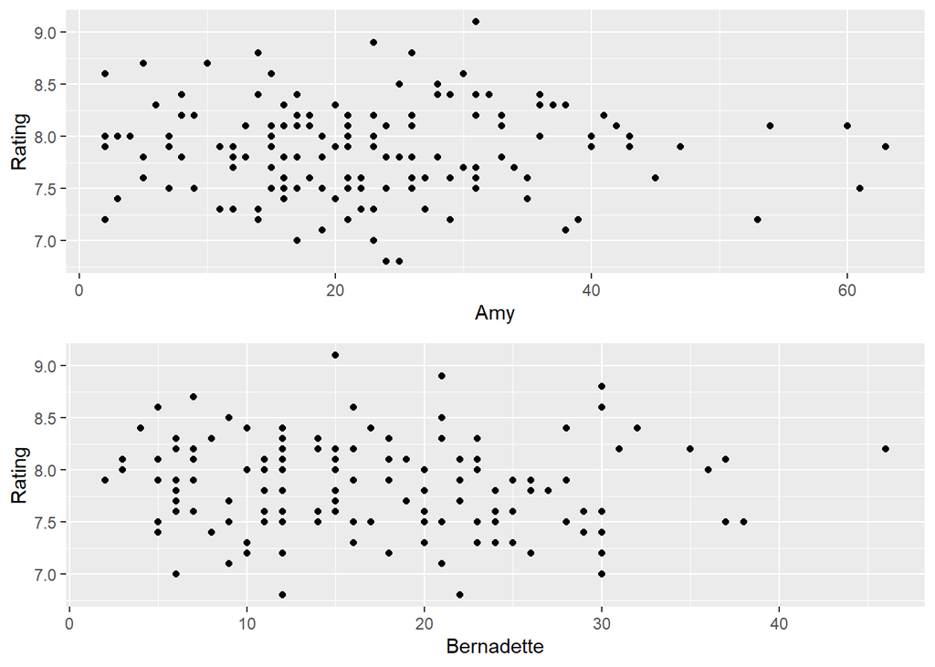

```r
p1 = ggplot(BigBangTheory3,aes(Amy,Rating)) + geom_point()
p2 = ggplot(BigBangTheory4,aes(Bernadette,Rating)) + geom_point()
grid.arrange(p1,p2)
```

The initial graphs seem to not indicate any sort of relationship.

Firstly let us explore the effect of Amy on the ratings:

```r
lmod3 = lm(Rating~Season+Director+ChuckLorre+Leonard+Sheldon+Penny+Howard+Raj+Leslie+Bernadette+Amy+Stuart+Emily+Mary+Zack+Bert+Janine+Wil+Day, BigBangTheory3)
lmodr3 = step(lmod3, trace=FALSE)
summary(lmodr3)
```

```
Call:
lm(formula = Rating ~ Season + Leonard + Penny + Amy + Day, data = BigBangTheory3)

Residuals:
     Min       1Q   Median       3Q      Max
-0.76105 -0.22228 -0.02214  0.17487  1.40881

Coefficients:
             Estimate Std. Error t value Pr(>|t|)
(Intercept)  8.590024   0.193621  44.365  < 2e-16 ***
Season      -0.131819   0.015341  -8.592  1.1e-14 ***
Leonard     -0.003132   0.002135  -1.467   0.1444
Penny        0.004029   0.002244   1.796   0.0746 .
Amy          0.003436   0.002450   1.402   0.1630
DayThursday  0.157284   0.091298   1.723   0.0870 .
---
Signif. codes:  0 '***' 0.001 '**' 0.01 '*' 0.05 '.' 0.1 ' ' 1

Residual standard error: 0.3448 on 148 degrees of freedom
Multiple R-squared:  0.3908,    Adjusted R-squared:  0.3702
F-statistic: 18.99 on 5 and 148 DF,  p-value: 1.461e-14
```

Amy is an insignificant predictor in the model, yet it was chosen to be in the model so it may have slight explanatory power.  
The model assumptions do hold for lmodr3.

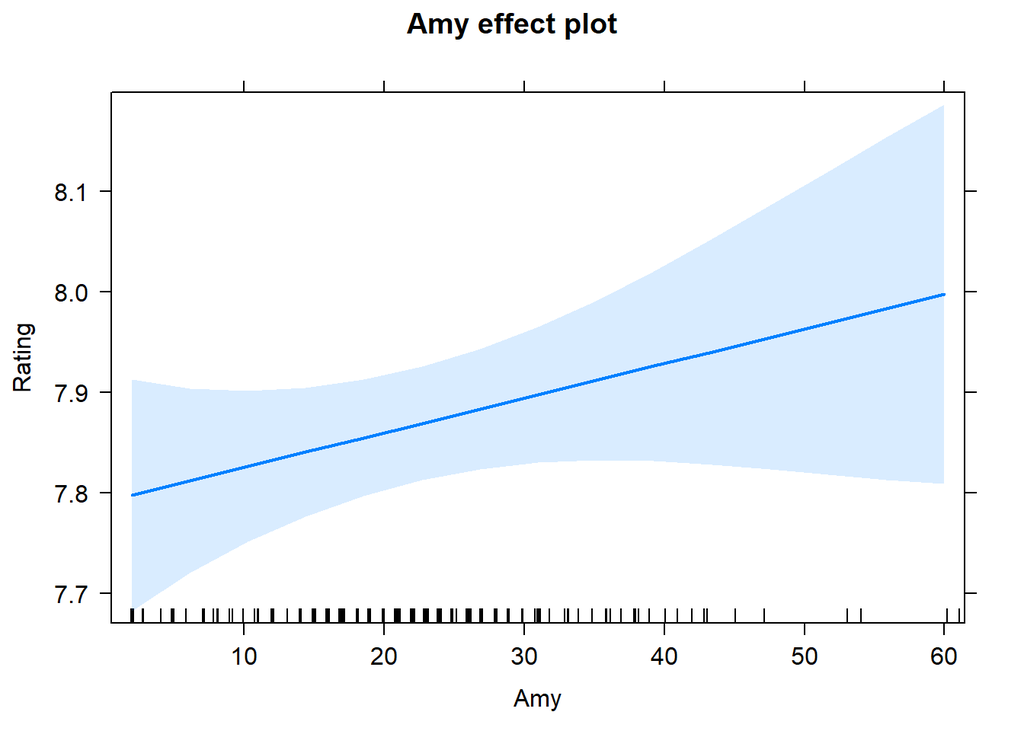

```r
plot(effect("Amy",lmodr3))
```

There appears to be a slight positive correlation between Amy and the ratings, however this is statistically insignificant as you can see by the wide confidence bands.

Now exploring the effect of Bernadette on the Ratings:

```r
lmod4 = lm(Rating~Season+Director+ChuckLorre+Leonard+Sheldon+Penny+Howard+Raj+Leslie+Bernadette+Amy+Stuart+Emily+Mary+Zack+Bert+Janine+Wil+Day, BigBangTheory4)
lmodr4 = step(lmod4, trace=FALSE)
summary(lmodr4)
```

```
Call:
lm(formula = Rating ~ Season + Amy + Day, data = BigBangTheory4)

Residuals:
     Min       1Q   Median       3Q      Max
-0.76533 -0.22628 -0.03658  0.18221  1.40169

Coefficients:
             Estimate Std. Error t value Pr(>|t|)
(Intercept)  8.499079   0.166762  50.965  < 2e-16 ***
Season      -0.124673   0.016323  -7.638 2.82e-12 ***
Amy          0.004118   0.002486   1.656   0.0999 .
DayThursday  0.193634   0.094870   2.041   0.0431 *
---
Signif. codes:  0 '***' 0.001 '**' 0.01 '*' 0.05 '.' 0.1 ' ' 1

Residual standard error: 0.3466 on 144 degrees of freedom
Multiple R-squared:  0.3624,    Adjusted R-squared:  0.3491
F-statistic: 27.28 on 3 and 144 DF,  p-value: 4.961e-14
```

The model did not actually include Bernadette, suggesting it is a predictor with no explanatory power.

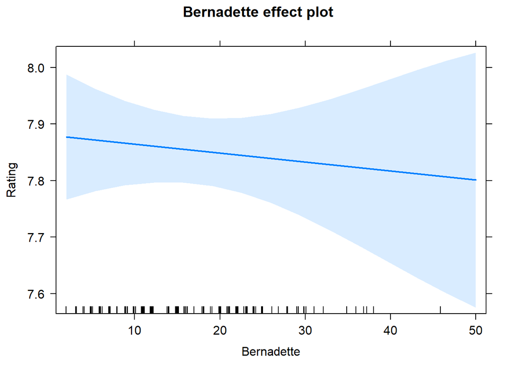

```r
lmodr4 = lm(Rating ~ Season + Amy + Day + Bernadette, BigBangTheory4)
plot(effect("Bernadette",lmodr4))
```

A slight negative effect is shown, but since the confidence band is very wide this is very statistically insignificant.  
The model assumptions do hold for lmodr4.

We can conclude that neither the introduction of Amy or Bernadette as major characters had an impact on the Ratings.

## 5. Other Comments

### 5.1 Raj

Viewers of the Big Bang Theory will know that Raj is known for his quietness, but are there particular characters who encourage or discourage him from speaking?

To test this, let us form a model with ‘Raj’ as the response and the other characters as the predictors.

```r
rmod = lm(Raj ~ Leonard + Sheldon + Penny + Howard + Leslie + Bernadette + Amy + Stuart + Emily + Mary + Zack + Bert + Janine + Wil, BigBangTheory)
rmodr = step(rmod, trace=FALSE)
summary(rmodr)
```

```
Call:
lm(formula = Raj ~ Leonard + Sheldon + Penny + Howard + Leslie +
    Bernadette + Emily, data = BigBangTheory)

Residuals:
    Min      1Q  Median      3Q     Max
-23.877  -7.564  -1.808   6.175  45.636

Coefficients:
            Estimate Std. Error t value Pr(>|t|)
(Intercept) 38.61563    4.65114   8.302 9.82e-15 ***
Leonard     -0.12263    0.04690  -2.615 0.009536 **
Sheldon     -0.17867    0.05239  -3.411 0.000769 ***
Penny       -0.15874    0.05353  -2.966 0.003350 **
Howard       0.22296    0.06335   3.519 0.000524 ***
Leslie      -0.37042    0.23538  -1.574 0.116962
Bernadette  -0.37301    0.08345  -4.470 1.25e-05 ***
Emily        0.63946    0.25037   2.554 0.011316 *
---
Signif. codes:  0 '***' 0.001 '**' 0.01 '*' 0.05 '.' 0.1 ' ' 1

Residual standard error: 11.19 on 223 degrees of freedom
Multiple R-squared:  0.229, Adjusted R-squared:  0.2048
F-statistic:  9.46 on 7 and 223 DF,  p-value: 2.85e-10
```

The model assumptions do hold for rmodr.

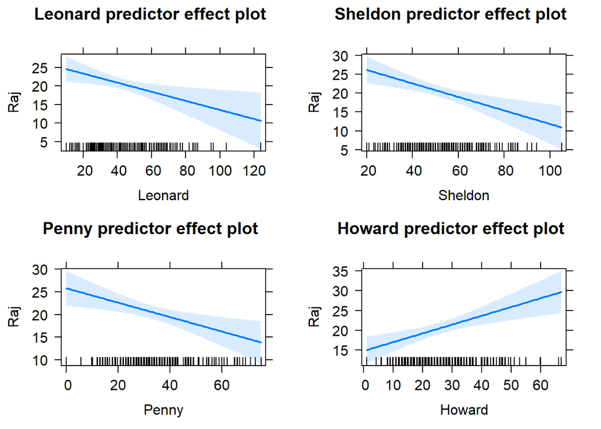

```r
plot(predictorEffects(rmodr, ~ Leonard + Sheldon + Penny + Howard))
```

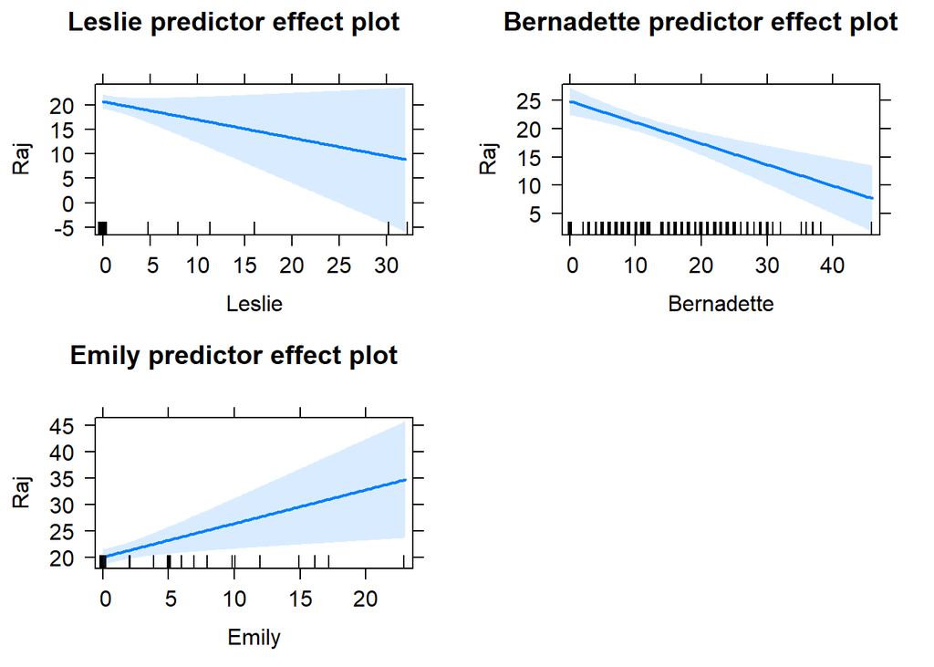

```r
plot(predictorEffects(rmodr, ~ Leslie + Bernadette + Emily))
```

From this we see that the significant predictors are Leonard, Sheldon, Penny, Howard, Bernadette, and Emily. The characters who discourage Raj from speaking are Leonard, Sheldon, Penny, and Bernadette. Howard and Emily instead appear to encourage Raj to speak.

As we know from the introduction to this report the number of lines of characters are correlated. This could be because there are characters who live or work together for example.  
We revisit the correlation table:

```r
BigBangTheory2 %>% select(AirDate,Raj,Leonard,Sheldon,Penny,Howard,Bernadette,Emily) %>% cor()
```

```
               AirDate         Raj    Leonard     Sheldon       Penny
AirDate     1.00000000  0.16482354 -0.4937715 -0.34748122 -0.19687782
Raj         0.16482354  1.00000000 -0.2210169 -0.22814496 -0.21290927
Leonard    -0.49377148 -0.22101694  1.0000000  0.30051432  0.22903901
Sheldon    -0.34748122 -0.22814496  0.3005143  1.00000000  0.05191438
Penny      -0.19687782 -0.21290927  0.2290390  0.05191438  1.00000000
Howard     -0.05864457  0.25371584 -0.1920238 -0.22618262 -0.14519379
Bernadette  0.57397154 -0.03663534 -0.4537769 -0.41935384 -0.14103836
Emily       0.20311041  0.15541414 -0.1380117 -0.07621608  0.06435464
                  Howard  Bernadette         Emily
AirDate    -0.0586445653  0.57397154  0.2031104052
Raj         0.2537158353 -0.03663534  0.1554141444
Leonard    -0.1920237763 -0.45377690 -0.1380116850
Sheldon    -0.2261826172 -0.41935384 -0.0762160774
Penny      -0.1451937900 -0.14103836  0.0643546402
Howard      1.0000000000  0.22240286 -0.0003984016
Bernadette  0.2224028634  1.00000000  0.0970574808
Emily      -0.0003984016  0.09705748  1.0000000000
```

In the introduction it was discussed that Leonard, Penny and Sheldon are all positively correlated to each other, but negatively correlated against Howard and Raj, who have a positive correlation with each other. This means that it is hard to determine which of Leonard, Penny and Sheldon drove the negative relationship with Raj - from the linear model it is implied they are all significant but since they heavily influence each other it is hard to give a definitive statement as to what specifically caused the negative relationship.

From our general knowledge of the show, this makes sense. Howard is Raj’s best friend, and Emily is a girl he briefly dates, therefore you would expect them to encourage him to talk more. Bernadette is Howard’s wife, so when Howard is spending time with her he is not spending time with Raj - meaning Raj speaks less. The discouragement from Leonard, Sheldon and Penny may be due to the fact that the plot generally does not have them interact with eachother often, so episodes that are more centric towards them are less likely to have Raj included. So the ‘discouragement’ and ‘encouragement’ from other characters to make Raj speak more could just be a consequence of the plot, as the only information we have is the lines spoken by each character in each episode, with no knowledge as to what these lines actually are.

## 6. Findings

From our analysis we have found that the popularity of The Big Bang Theory is influenced by a number of factors regarding the content and production of its episodes. The biggest change in the ratings of episodes was exhibited as the show progressed over time. The show saw some of its most consistently high ratings in the first seasons, before a gradual but notable drop in popularity into the later stages. There was little evidence for a pattern relating to any of the show’s several writers and directors including renowned writer Chuck Lorre, known as the ‘King of Sitcoms’.